# Spatial Metrics

From [SMAMMUNITY: SMall mAMMal commUNITY](https://github.com/katekathrynkat/smammunity)

**Kate Culhane**, Dept. of Ecology, Evolution, and Marine Biology, UC Santa Barbara  
kathrynculhane@ucsb.edu

**Publication:** Culhane, K., R. Sollmann, A.M. White, G.L. Tarbill, S. Cooper, M.A. Moritz, H.S. Young. (2021). Small mammal functional traits and vegetation characteristics mediate community responses to fire severity. Ecological Applications. Manuscript submitted for initial review.

**Source code:** 03_spatial_metrics.Rmd

## Spatial Datasets

#### Monitoring Trends in Burn Severity (MTBS)

- Spatial products created using differenced Normalized Burn Ratio (dNBR) from Landsat reflectance imagery of pre-fire and post-fire conditions at 30-m resolution
- **Thematic Burn Severity:** classifications of burn severity
  - 0 = outside the burn boundary
  - 1 = unburned-low severity within the fire perimeter
  - 2 = low severity
  - 3 = moderate severity
  - 4 = high severity
  - 5 = increased greenness (increased post-fire vegetation)
- Data available online: https://www.mtbs.gov/

#### LANDFIRE

- Spatial products created using predictive landscape models that incorporate field-referenced data, satellite imagery, and biophysical gradient layers
- **Existing Vegetation Cover (EVC):** Vertically projected percent cover of the live canopy layer for a specific area
- **Existing Vegetation Type (EVT):** Complexes of plant communities
  - Converted to California Wildlife Habitat Relationships (CWHR) classes for analysis
- Retrieved data from pre-burn (2012; LF 1.3.0) and post-burn (2014; LF 1.4.0)
  - LANDFIRE data are not available annually because they represent a composite of remote sensing data from a range of 2-3 years.
  - 2016 data (corresponding to the field sampling period) were not used because they were developed using different methods from 2012 and 2014.
- Data available online: https://landfire.gov/

## Burn severity map

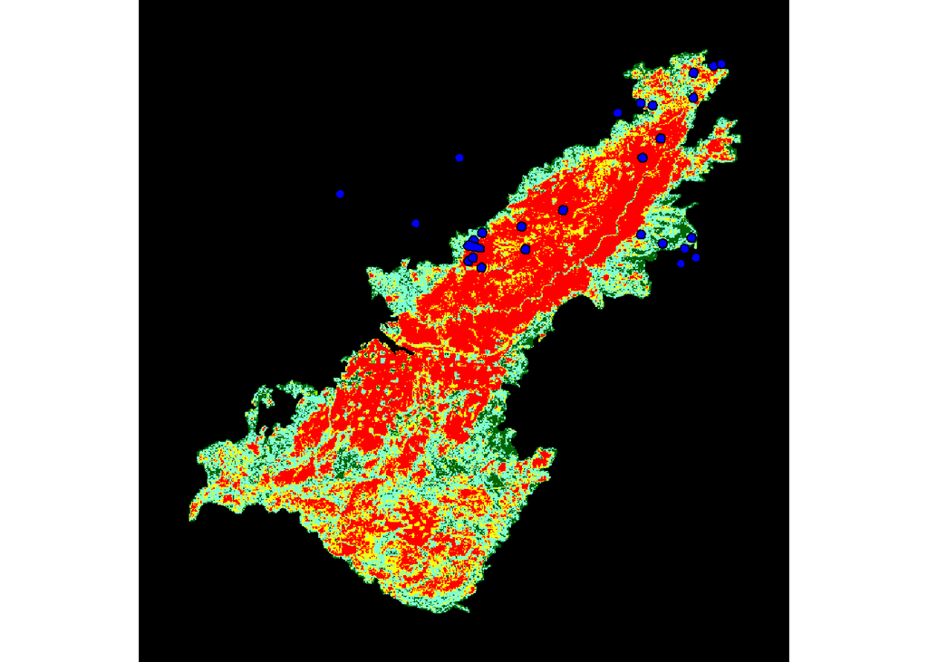

- Burn severity data from MTBS (Monitoring Trends in Burn Severity)
- Buffered mammal grids shown in blue
  - Buffer is equal to the largest home range of a trapped mammal: *G. sabrinus*, 0.04 km<sup>2</sup>

## Spatial metrics

Calculated to justify fire severity categories

**Average severity:** average MTBS pixel value within buffered site boundaries

```r
# Create data frame with a row for each pixel in each expanded site

buffsite_pixels <- data.frame(site = character(), # blank data frame
                              severity = numeric())

for (i in unique(grid_corners_df$site)) {
  df <- extract(mtbs_raster, buffsites_list[[i]], df = TRUE) %>% # extract pixel information within each buffered site polygon
    mutate(site = i) %>%
    dplyr::rename(severity = ca3878212060420140913_20130730_20150805_dnbr6) %>%
    select(site, severity)
  buffsite_pixels <- rbind(buffsite_pixels, df) # add pixel information to df, one row per pixel
}

# Summary of % of each severity within each buffered site

buffpixel_summary <- buffsite_pixels %>%
  group_by(site, severity) %>%
  summarize(pixels = length(severity)) %>%
  group_by(site) %>%
  mutate(prop = pixels/sum(pixels))

# Calculate average severity value for each site

buffsite_sev_avg <- buffsite_pixels %>%
  group_by(site) %>%
  summarize(avg = mean(severity))
```

**Distance to burn boundary:** distance from each site centroid to the nearest burn boundary (m)

```r
# Calculate distance to burn boundary

burn_edge <- as(bndy_shp, 'SpatialLinesDataFrame')

distances <- t(gDistance(sites_aea, burn_edge, byid = TRUE))

distance_to_edge <- data.frame(sites_aea$site, distances) %>%
  rename(site = sites_aea.site) %>%
  full_join(site_meta) %>%
  mutate(distance = case_when(
    severity == 'unb' ~ -X0,
    TRUE ~ X0
  ))
```

## Pre- vs. post- disturbance habitat characteristics

### Existing Vegetation Type (EVT)

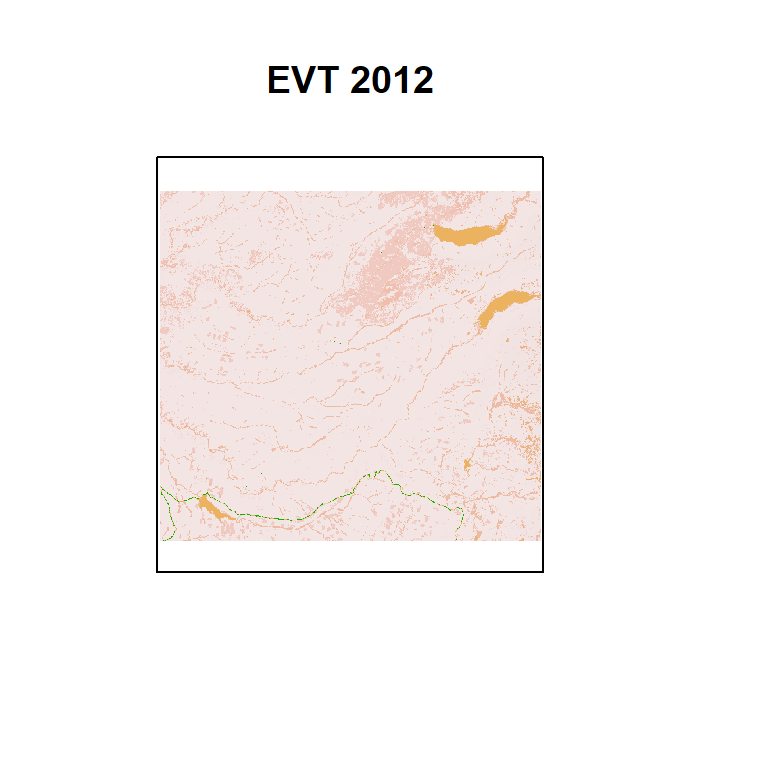

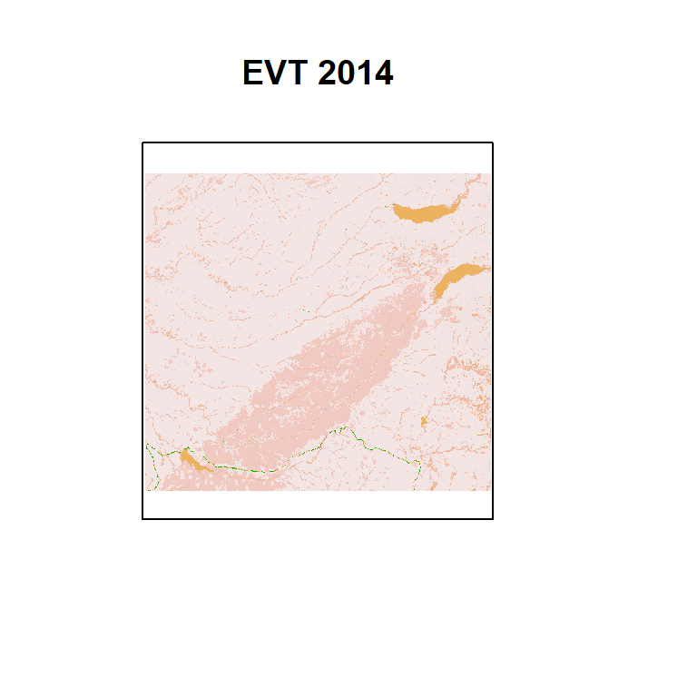

### Existing Vegetation Cover (EVC)

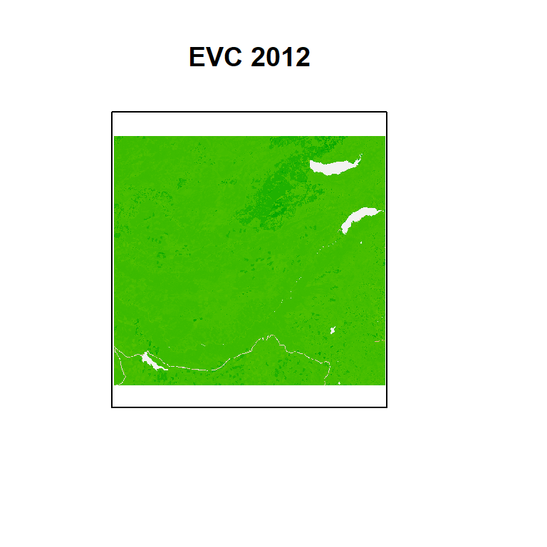

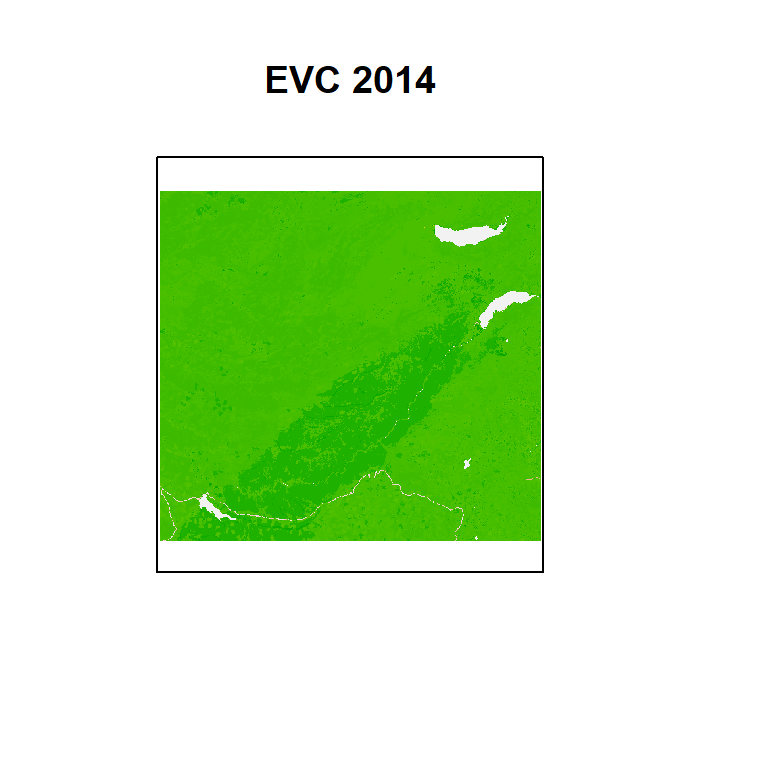